# Distributions

You may have noticed that numerical data is often summarized with the *average* value. For example, the quality of a high school is sometimes summarized with one number: the average score on a standardized test. Occasionally a second number is reported: the *standard deviation*. So, for example, you might read a report stating that scores were 680 plus or minus 50 (the standard deviation). Note that the report has summarized an entire vector of scores with with just two numbers. Is this appropriate? Is there any important piece of information we are missing by only looking at this summary rather than the entire list?

Our first data visualization building block is learning to summarize lists of factors or numeric vectors. The most basic statistical summary of a list of objects or numbers is it’s distribution. Once a vector has been summarized as a distribution, there are several data visualization techniques to effectively relay this information.

### Data types

We will be working with two types of variables: *categorical* and *numeric*. Each can be divided into two other groups: categorical can be ordinal or not, and numerical variables can be discrete or continuous.

A variable that is defined by a small number of groups is known as *categorical data*. Two simple examples are sex (male or female), and regions (Northeast, South, North Central, West). Some categorical data can be ordered, for example spiciness (mild, medium, hot), even if they are not numbers per se. In statistics text books they sometimes refer to these as *ordinal* data.

Examples of numerical data include population sizes, murder rates, and heights. Note that some numerical data can be treated as ordered categorical. We can further divide numerical data into *continuous* and *discrete*. Continuous variables are those that can take any value, such as heights, if measured with enough precision. For example, a pair of twins may be 68.12 and 68.11 inches respectively. Counts, such as population sizes, are discrete because they have to be round (whole) numbers.

Note that discrete numeric data can be considered ordinal. Although this is technically true, we usually reserve the term *ordinal data* for variables belonging to a small number of different groups, with each group having many members. In contrast, when we have many groups with few cases in each group, we typically refer to them as discrete numerical variables. So, for example, the number of packs of cigarettes a person smokes a day, rounded to the closest pack, would be considered ordinal while the actual number of cigarettes would be considered a numerical variable. But indeed, there are examples that can be considered both when it comes to visualizing data.

### Motivating problem

Here we introduce a new motivating problem. It is an artificial one, but it will help us illustrate the concepts needed to understand distributions.

Pretend that we have to describe the heights of our classmates to [E.T.](https://en.wikipedia.org/wiki/E.T._the_Extra-Terrestrial), an extraterrestrial, that has never seen humans. As a first step we need to collect data. To do this, we ask students to report their heights in inches. We ask them to provide sex information because we know there are two different distributions. We collect the data and save it in a data frame:

```r
library(dslabs)
data(heights)
head(heights)
```

```
##      sex height
## 1   Male     75
## 2   Male     70
## 3   Male     68
## 4   Male     74
## 5   Male     61
## 6 Female     65
```

```r
dim(heights)
```

```
## [1] 1050    2
```

One way to convey the heights to E.T. is to simply send him this list of 1050 heights. But there are much more effective ways to convey this information and understanding the concept of a distribution will help. To simplify the explanation, at first we focus on male heights.

### Distribution Function

It turns out that, in some cases, the two numbers mentioned above (the mean and standard deviation) are pretty much all we need to understand the data. We will learn data visualization techniques that will help us determine when these two number summaries are appropriate. These same techniques will serve as an alternative for when two numbers are not enough.

The most basic statistical summary of a list of objects or numbers is it’s distribution. The simplest way to think of a distribution is as a compact description of a list with many entries. This concept should not be new for most of you. For example, with categorical data, the distribution simply describes the proportion of each unique category. For example, the sex represented in the heights dataset is:

```
##
##    Female      Male
## 0.2266667 0.7733333
```

This two category *frequency table* is the simplest form of a distribution we can form. We don’t really need to visualize it since one number describes everything we need to know: 23% are females and the rest are males. When there are more categories, a simple barplot describes the distribution. Here is an example with the US state regions:

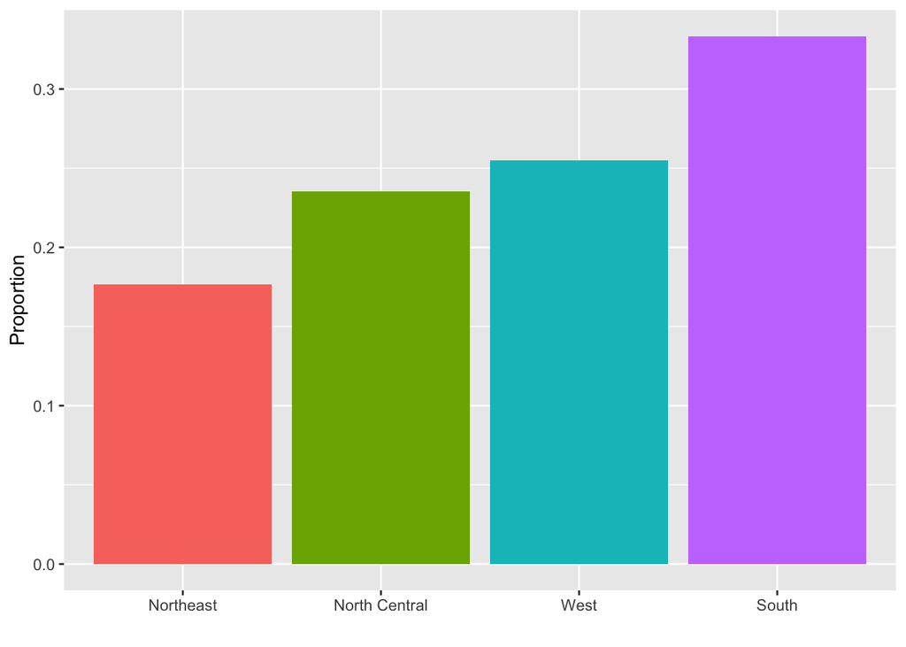

This particular plot is simply showing us four numbers: one for each category. We usually use barplots to display a few numbers. Although this particular plot, a graphical representation of a frequency table, does not provide much more insight than a table itself, it is a first a example of how we convert a vector into a plot that succinctly summarizes all the information in the vector. Once the data is numerical, the task of displaying distributions is more challenging.

### Cumulative Distribution Functions

Numerical data, that are not categorical, also have distributions. In general, when data is not categorical, reporting the frequency of each entry is not an effective summary since most entries are unique. For example, while several students reported a height of 68 inches, only one student reported a height of `68.503937007874` inches and only one student reported a height `68.8976377952756` inches. We assume that they converted from 174 and 175 centimeters respectively.

Statistics textbooks teach us that a more useful way to define a distribution for numeric data is to define a function that reports the proportion of the data below $a$ for all possible values of $a$. This function is called the cumulative distribution function (CDF). In Statistics the following notation is used:

$$F(a) = \mbox{Pr}(x \leq a)$$

Here is a plot of $F$ for the height data:

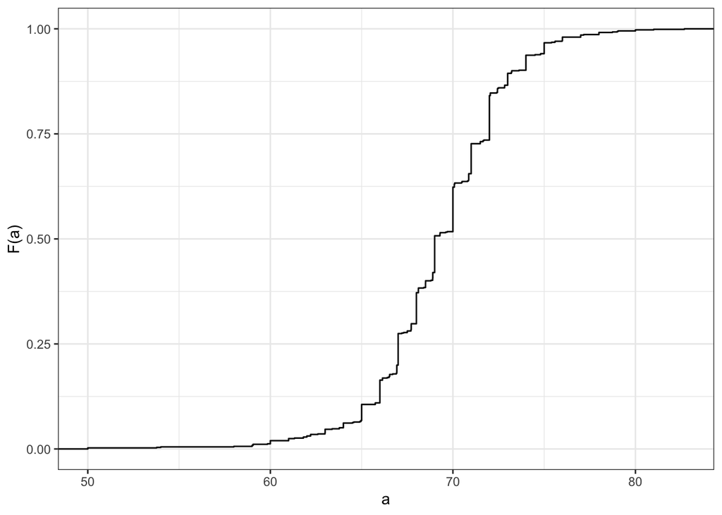

Empirical cummulative distribution function for male height.

Like the frequency table does for categorical data, the CDF defines the distribution for numerical data. From the plot we can see, for example, that 16.4% of the values are below 66, since $F(66)=$ 0.1637931, or that 84.1% of the values are below 72, since $F(72)=$ 0.841133, etc… In fact, we can report the proportion of values between any two heights, say $a$ and $b$ by computing $F(b) - F(a)$. This means that if we send the plot above to E.T., he will have all the information needed to reconstruct the entire list. Paraphrasing the expression “a picture is worth a thousand words”, in this case a picture is as informative as 812 numbers.

A final note: because CDFs can be defined mathematically, as opposed to using data as we do here, the word *empirical* is added to distinguish the two, and we use the term empirical CDF (ECDF) instead.

### Histograms

Although the CDF concept is widely discussed in statistics textbooks, the plot is actually not very popular in practice. The main reason is that it does not easily convey characteristics of interest such as: at what value is the distribution centered? Is the distribution symmetric? What ranges contain 95% of the values? Histograms are much preferred because they greatly facilitate answering such questions. Histograms sacrifice just a bit of information to produce plots that are much easier to interpret.

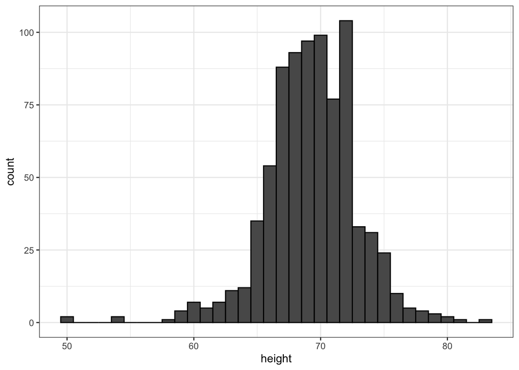

Note that a histogram is similar to a barplot but it differs in that the x-axis is numerical, not categorical.

## Smoothed Density

Smooth density plots are aesthetically more appealing than histograms. Here is what a smooth density plot looks like for our heights data:

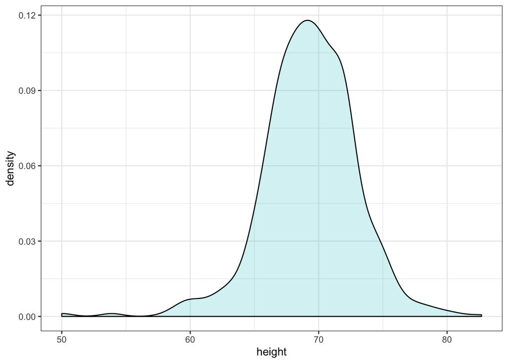

Note that we no longer have sharp edges at the interval boundaries and that many of the local peaks have been removed. Also, notice that the scale of the y-axis changed from counts to *density*.

To understand the smooth densities we have to understand *estimates*; a topic we don’t cover until a later lecture. However, we provide a heuristic explanation to help you understand the basics so you can use this useful data visualization tool.

The main new concept you have to understand is that we assume that our list of observed values comes from a much, much larger list of unobserved values. So in the case of heights, you can imagine our list of 1050 students comes from a hypothetical list containing all the heights of all the students in all the world measured very precisely. Let’s say there are 1,000,000 of these. This list of values, like any list of values, has a distribution and this is really what we want to report to E.T. since it is much more general. Unfortunately we don’t get to see it.

However, we make an assumption that helps us perhaps *approximate it*. Because we have 1,000,000 values, measured very precisely, we can make a histogram with very, very small bins. The assumption is that if we do this, consecutive bins will be similar, and this is what we mean by smooth: we don’t have big jumps. So here is a hypothetical histogram with bins of size 1:

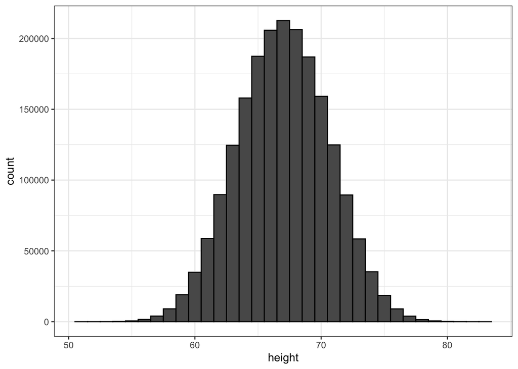

The smaller we make the bins the smoother the histogram gets. Here are the histograms with bin width of 1, 0.5 and 0.1:

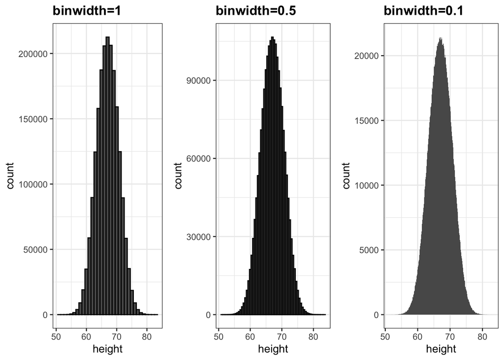

The smooth density is basically the curve that goes through the top of the histogram bars when the bins are very very small. To make the curve not depend on the hypothetical size of the hypothetical list, we compute the curve on frequencies rather than counts.

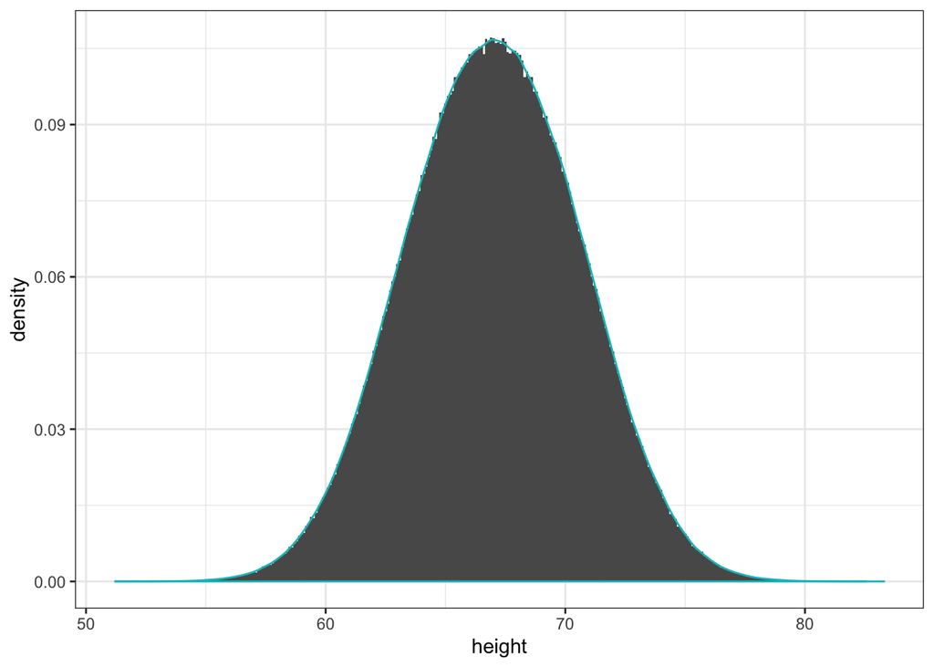

Now, back to reality. We don’t have millions of measurements, instead we have 812 and we can’t make a histogram with very small bins.

So instead we make the histogram, computing frequencies rather than counts, using bin sizes appropriate for our data, and we draw a smooth curve that goes through the tops of the histogram bars:

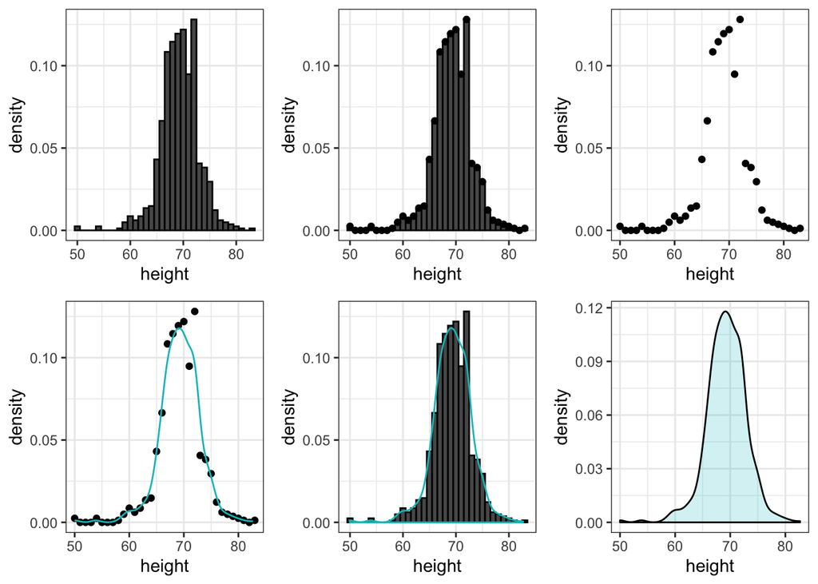

Note that *smooth* is a relative term. We can actually control the *smoothness* of the curve that defines the smooth density through an option in the function that computes the smooth density. Here are two examples using different degrees of smoothness on the same histogram:

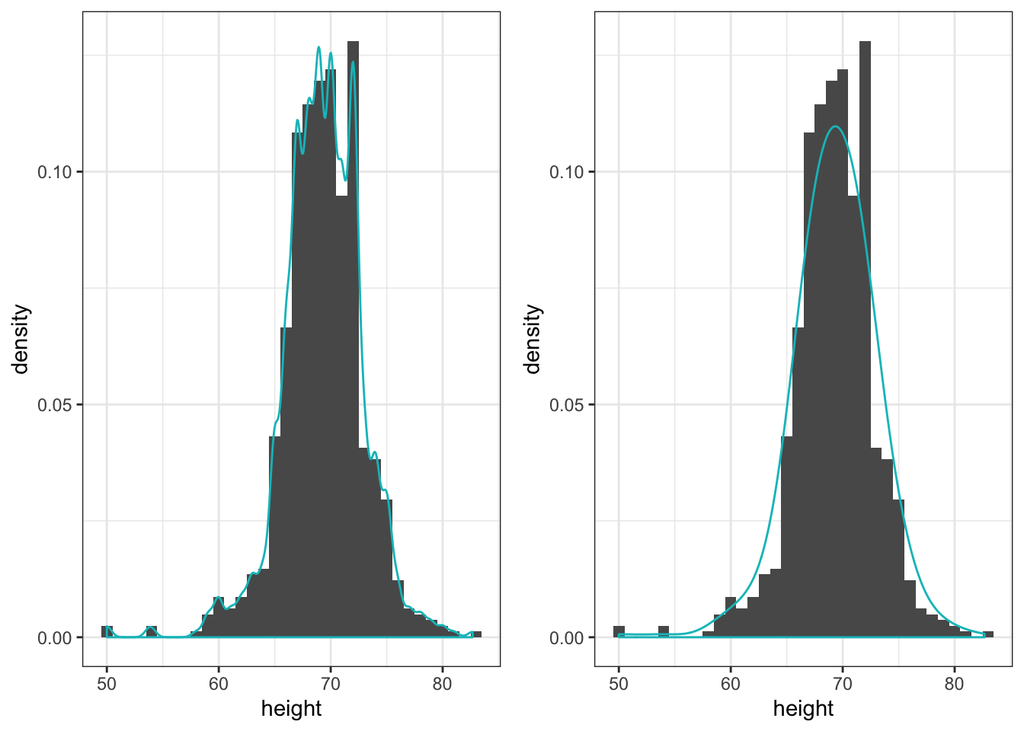

```r
p1 <- heights %>% filter(sex=="Male")%>% ggplot(aes(height)) +
  geom_histogram(aes(y=..density..), binwidth = 1) +
  geom_density(col="#00BFC4", adjust = 0.5) # Less smoothing

p2 <- heights %>% filter(sex=="Male") %>% ggplot(aes(height)) +
  geom_histogram(aes(y=..density..), binwidth = 1) +
  geom_density(col="#00BFC4", adjust = 2)   # More smoothing
grid.arrange(p1,p2, ncol=2)
```

We need to make this choice with care as the resulting visualizations can change our interpretation of the data. **We should select a degree of smoothness that we can defend as being representative of the underlying data**. In the case of height, we really do have reason to believe that the proportion of people with similar heights should be the same. For example, the proportion that is 72 inches should be more similar to the proportion that is 71, then to the proportion that is 78 or 65. This implies that the curve should be pretty smooth; more like the example on the right than on the left.

While the histogram is an assumption-free summary, the smoothed density is based on assumptions.

#### Interpreting the y-axis

Finally, we point out that interpreting the y-axis of a smooth density plot is not straight forward. It is scaled so that the area under the density curve adds up to 1. So if you imagine we form a bin with a base 1 unit in length, the y-axis value tells us the proportion of values in that bin. But this is only true for bins of size 1. For other sized intervals, the best way to determine the proportion of data in that interval is by computing the proportion of the total area contained in that interval. For example, here is the proportion of values between 65 and 68:

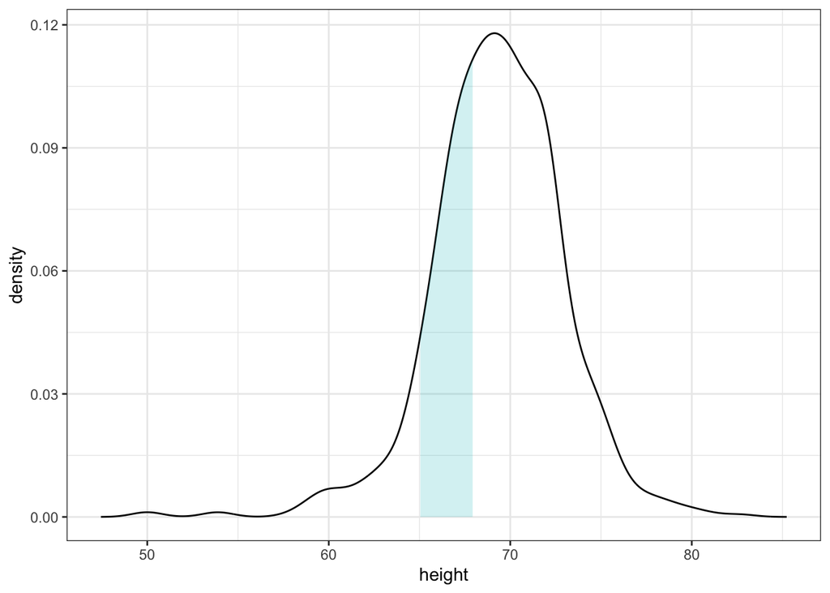

The proportion of this area is about 0.32, meaning that about that proportion is between 65 and 68 inches.

Understanding this we are ready to use the smooth density as a summary. For this dataset we would feel quite comfortable with the smoothness assumption and therefore with sharing this aesthetically pleasing figure with E.T., which he could use to understand our male heights data:

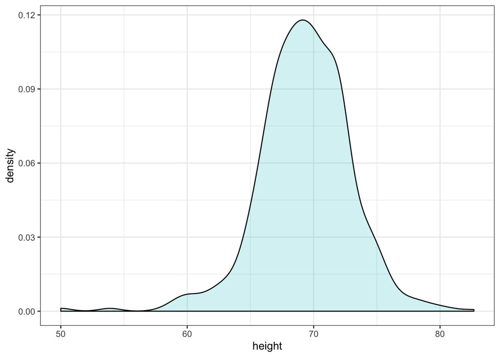

#### Densities Permit Stratification

As a final note, we point out that an advantage of smooth densities over histograms for visualization purposes is that it makes it easier to compare two distributions. This is in large part because the jagged edges of the histogram add clutter. Here is an example comparing male and female heights:

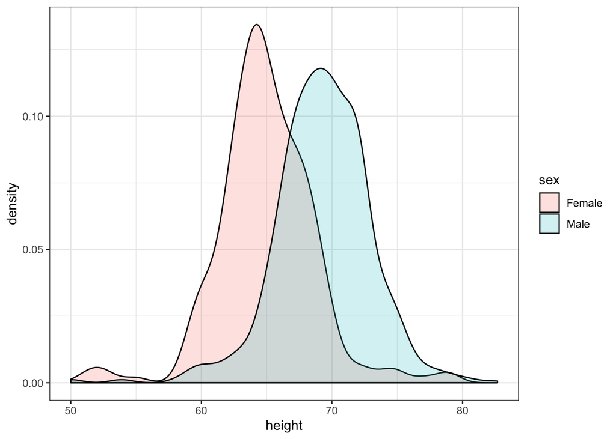

```r
heights %>% ggplot(aes(height, fill=sex)) + geom_density(alpha = 0.2)
```

`ggplot` automatically shades the intersecting region with a different color.

## Normal Distribution

Histograms and density plots provide excellent summaries of a distribution. But can we summarize even further? We often see the average and standard deviation used as summary statistics: a two number summary! To understand what these summaries are and why they are so widely used we need to understand the normal distribution.

The normal distribution, also known as the bell curve and as the Gaussian distribution, is one of the most famous mathematical concepts in history. A reason for this is that approximately normal distributions occur in many situations. Examples include gambling winnings, heights, weights, blood pressure, standardized test scores, and experimental measurement errors. There are explanations for this, but we explain this in a later lecture. Here we focus on how the normal distribution helps us summarize data.

Rather than using data, the normal distribution is defined with a mathematical formula. For any interval $(a,b)$, the proportion of values in that interval can be computed using this formula:

$$\mbox{Pr}(a < x < b) = \int_a^b \frac{1}{\sqrt{2\pi}s} e^\left\{-\frac{1}{2}\left( \frac{x-m}{s} \right)^2\right\} \, dx$$

You don’t need to memorize or understand the details of the formula. But note that it is completely defined by just two parameters $m$ and $s$, the rest of the symbols in the formula represent the interval ends that we determine, $a$ and $b$, and known mathematical constants $\pi$ and $\mathrm{e}$. These two parameters, $m$ and $s$, are referred to as the *average*, also called the *mean*, and the *standard deviation* (SD) of the distribution respectively.

The distribution is symmetric, centered at the average, and most values (about 95%) are within 2 SDs from the average. Here is what it looks like when the average is 0 and the SD is 1:

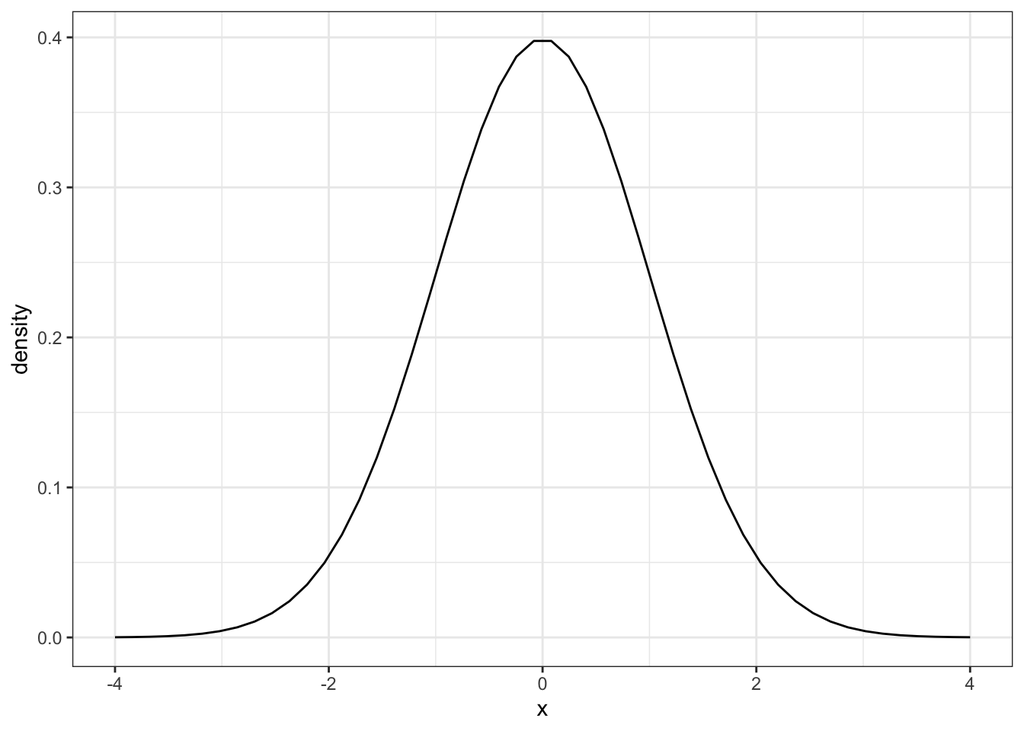

The fact that the distribution is defined by just two parameters implies that if a dataset is approximated by a normal distribution, all the information needed to describe the distribution can be encoded in just two numbers: the average and the standard deviation, which we now define for an arbitrary list of numbers.

For a list of numbers contained in a vector `x`, the average is defined as

```r
average <- sum(x) / length(x)
```

and the SD is defined as

```r
SD <- sqrt( sum( (x-average)^2) / length(x) )
```

which can be interpreted as the average distance between values and their average.

Let’s compute the values for the height of males which we will store in the object $x$:

```r
index <- heights$sex == "Male"
x <- heights$height[index]
```

The pre-built functions `mean` and `sd` [Footnote: SD divided by n-1] can be used here:

```r
average <- mean(x)
SD <- sd(x)
c(average = average, SD = SD)
```

```
##   average        SD
## 69.314755  3.611024
```

Here is a plot of the smooth density and the normal distribution with mean = 69.3147549 and SD = 3.6110237

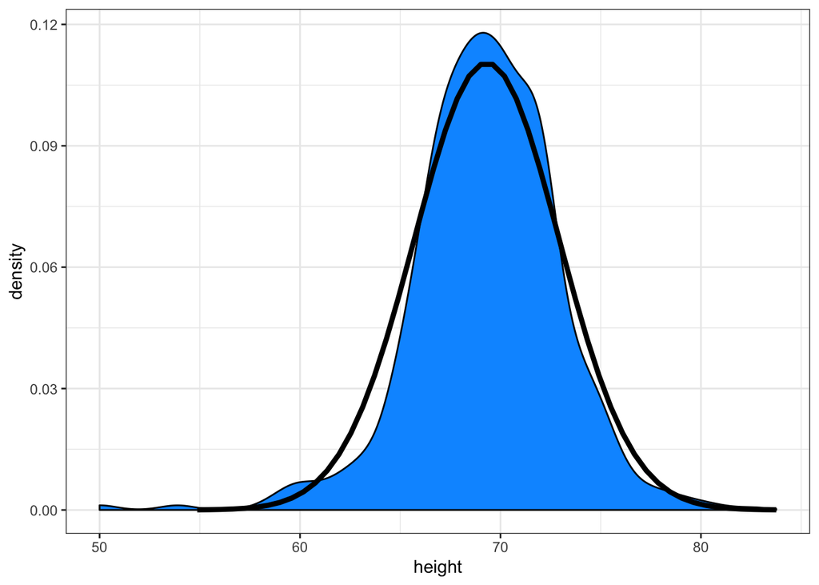

We note that the it does appear to be quite a good approximation. We now will see how well this approximation works at predicting proportions of values within intervals.

#### Standardized units

For data that is approximately normally distributed it is convenient to think in terms of *standard units*. The standard unit of a value tells us how many standard deviations away from the average it is. Specifically, for a value $x$ we define it as $z = (x-\mbox{average})/\mbox{SD}$. If you look back at the formula for the normal distribution you notice that what is being exponentiated is $- z^2$. The maximum of of $e^{(-z^2/2)}$ is when $z=0$ which explains why the maximum of the distribution is at the mean. It also explains the symmetry since $- z^2$ is symmetric around 0.

If we convert the normally distributed data to standard units we can quickly know if, for example, a person is about average ($z = 0$), one of the largest ($z = 2$), one of the smallest ($z = -2$) or an extremely rare occurrence ($z > 3$ or $z < -3$). Note that it does not matter what the original units are, these rules apply to data that is approximately normal.

In R we can obtain standard units using the function `scale`:

```r
z <- scale(x)
```

Now to see the proportion of men within 2 SDs from the average we simply type:

```r
mean(abs(z) < 2)
```

```
## [1] 0.9495074
```

Note that it is about 95% which is what the normal distribution predicts! To further confirm that in fact the approximation is a good one, we can use quantile-quantile plots.

### Quantile-quantile QQ plots

A systematic way to assess how well the normal distribution fits the data is to check if the observed and predicted proportions match. In general, the approach of the QQ-plot is as follows:

1. Define a series of proportions $p = 0.05,\dots , 0.95$
2. For each $p$ determine the value $q$ so that the proportion of values in the data below $q$ is $p$. The $q$s are referred to as the *quantiles*.

To give a quick a example, for the male heights data we have that

```r
mean(x <= 69.5)
```

```
## [1] 0.5147783
```

This means 50% are shorter than or equal to 69.5 inches. This implies that if $p = 0.50$ then $q = 69.5$.

Now we define a series of $p$s:

```r
p <- seq(0.05, 0.95, 0.05)
```

If the quantiles for the data match the quantiles for the normal then it must be because the data follows a normal distribution.

To obtain the quantiles from the data we can use the `quantile` function like this:

```r
observed_quantiles <- quantile(x, p)
```

To obtain the theoretical normal distribution quantiles, with the corresponding average and SD, we use the `qnorm` function:

```r
theoretical_quantiles <- qnorm(p, mean = mean(x), sd = sd(x))
```

To see if they match or not, we plot them against each other and draw the identity line:

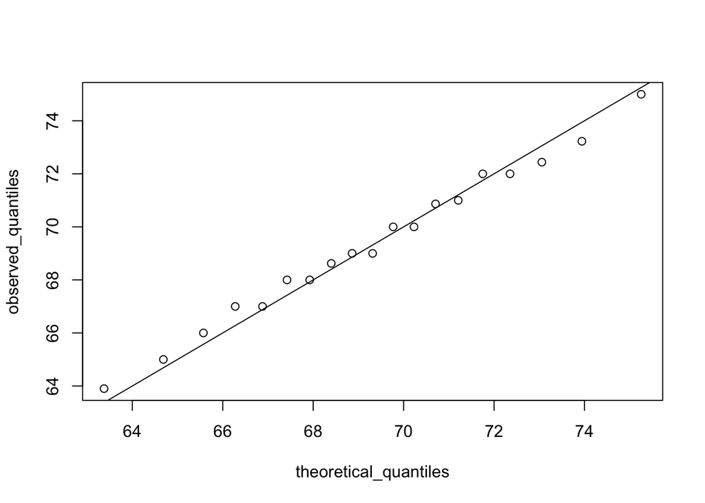

```r
plot(theoretical_quantiles, observed_quantiles)
abline(0,1)
```

Note that this code becomes much cleaner if we use standard units:

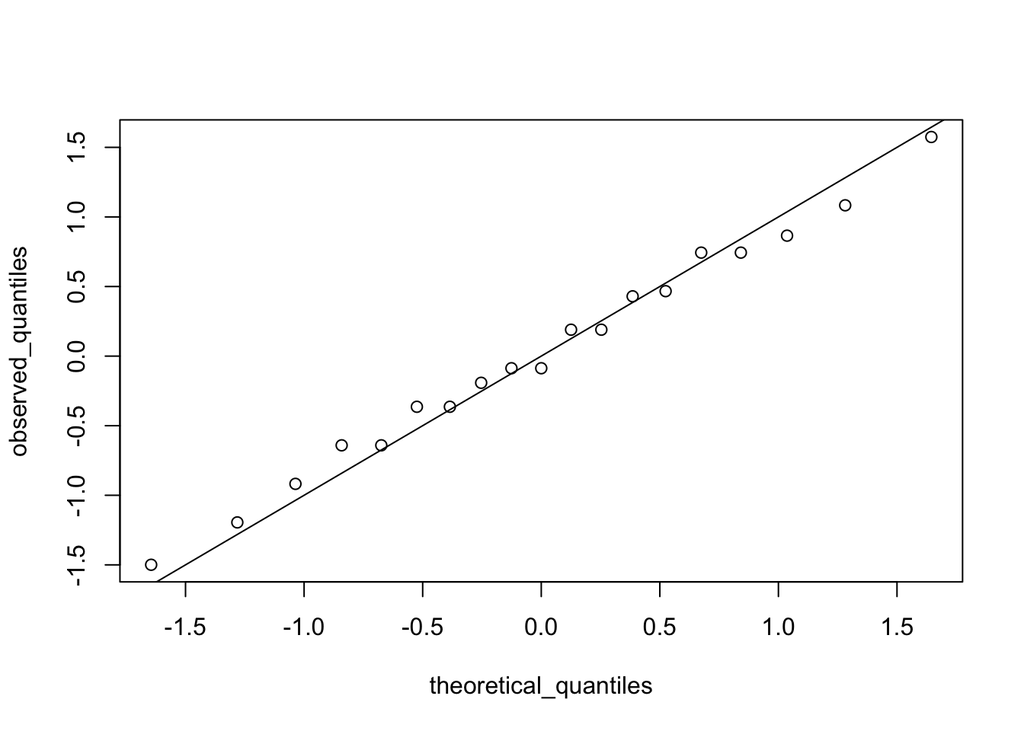

```r
observed_quantiles <- quantile(z, p)
theoretical_quantiles <- qnorm(p)
plot(theoretical_quantiles, observed_quantiles)
abline(0,1)
```

#### Percentiles

Before we move on, let’s define some terms that are commonly used in exploratory data analysis.

*Percentiles* are a special case of *quantiles* that are commonly used. The percentiles are the quantiles you obtain when setting the $p$ at $0.01, 0.02, ..., 0.99$. We call, for example, the case of $p = 0.25$ the 25th percentile, which gives us a number for which 25% of the data is below. The most famous percentile is the 50th, also known as the *median*.

Note that for the normal distribution the *median* and average are the same, but this is generally not the case.

Another special case that receives a name are the *quartiles* which are obtained when setting $p = 0.25,0.50$, and $0.75$.

### Summarizing male heights with two numbers

Using the histogram, density plots and qq-plots we have become convinced that the male height data is well approximated with a normal distribution. In this case, we report back to E.T. a very succinct summary: Male heights follow a normal distribution with an average of 69.3147549 inches and a SD of 3.6110237 inches. With this information E.T. will have everything he needs to know and what to expect when he meets our male students.

### Boxplots

To introduce boxplots we will go back to the US murders data. Suppose we want to summarize the murder rate distribution. Using the data visualization technique we have learned we can quickly notice that the normal approximation does not apply here:

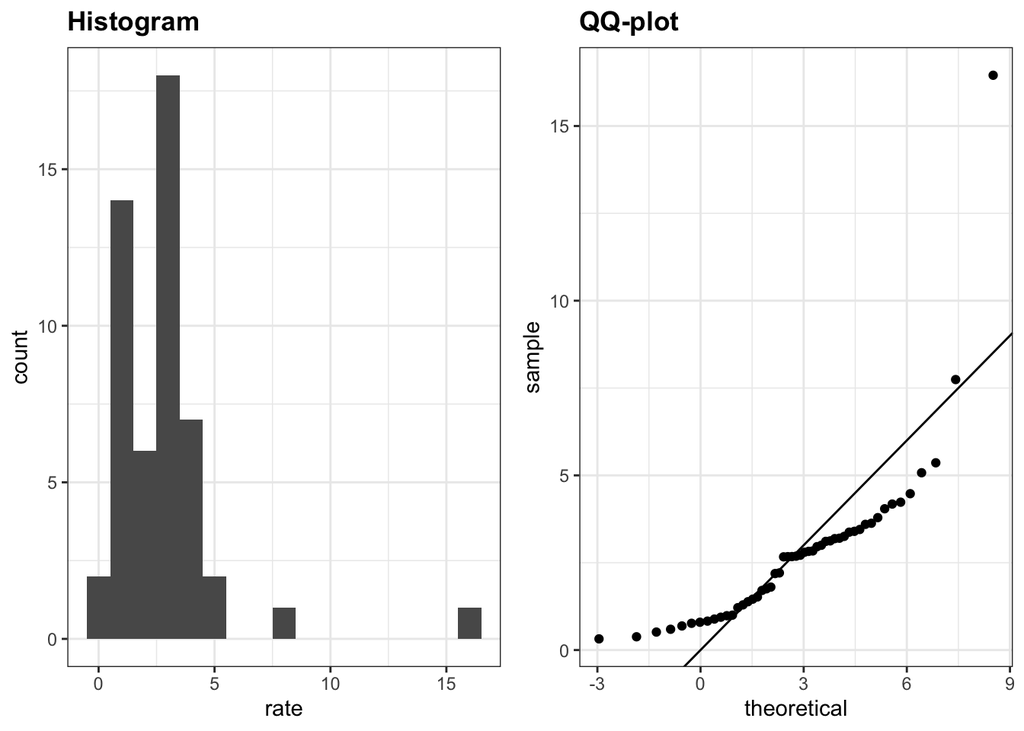

In this case, the histogram, or a smooth density plot, would serve as a relatively succinct summary.

Now, suppose those used to receiving just two numbers as summaries ask us for a more compact summary.

Here Tukey offers some advice. Provide a five number summary composed of the range along with the quartiles (the 25th, 50th, and 75th percentiles). Tukey further suggested that we ignore *outliers* when computing the range and instead plot these as independent points. We provide a detailed explanation of outliers later. Finally, he suggested we plot these numbers as a “box” with “whiskers” like this:

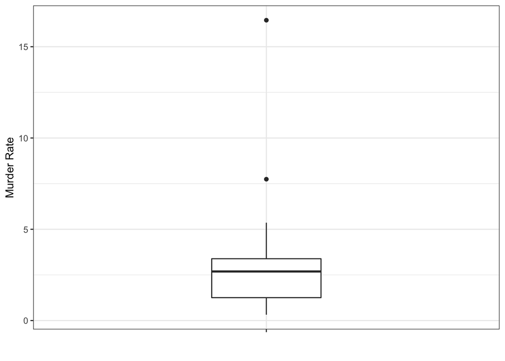

with the box defined by the 25% and 75% percentile and the whiskers showing the range. The distance between these two is called the *interquartile* range. The two points are outliers according to Tukey’s definition. The median is shown with a horizontal line. Today, we call these *boxplots*.

From just this simple plot we know that the median is about 2.5, that the distribution is not symmetric, and that the range is 0 to 5 for the great majority of states with two exceptions.

They are even more useful when we want to quickly compare two or more distributions. For example, here are the heights for men and women.

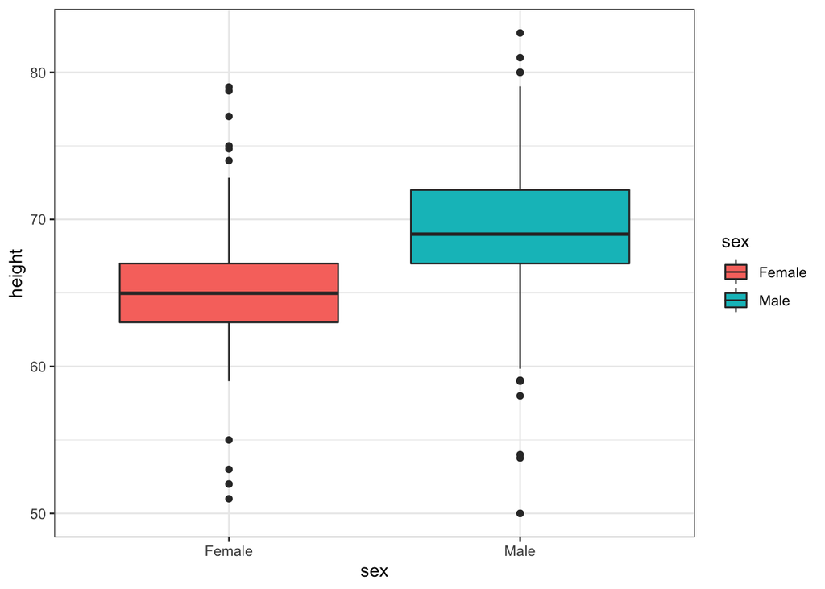

```r
heights %>% ggplot(aes(x=sex, y=height, fill=sex)) +
  geom_boxplot()
```

The plot immediately reveals that males are, on average, taller than females. The standard deviations appear to be similar.

### Are women heights normally distributed?

Note we have to give E.T. a full summary of our heights and we have not yet summarized female heights. We expect that they will follow a normal distribution, just like males. However, exploratory plots reveal that the approximation is not as useful:

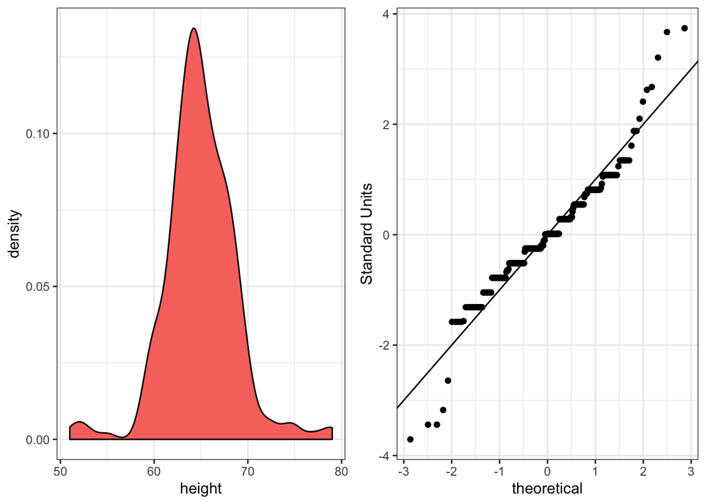

We see something we did not see for the males. The density plot has a second “bump”. Also the qqplot shows that the highest points tend to be taller than expected by the normal distribution. When reporting back to E.T. we might need to provide a histogram rather than just the average and standard deviation for the female heights.